# Schleswig-Holstein Wars Sentimen

Dicte Mikkelsen, Alberte Thomsen, Sophie Løbner & Katrine Pedersen

2025-05-13

# Overview

This document preforms a historical sentiment analysis of Danish newspaper text from the **Schleswig-Holstein Wars (1848-1851 and 1864-1865)**. We use **two Danish sentiment lexicons**m and compare sentiment trends over time for each war.

We guide through: - **Data collection** from the Danish State Library API, - **Text preprocessing and tokenization**, - **Sentiment analysis** using both a custom Danish dictionary and AFINN-da, - **Visualization and interpretation** of the results.

# 1. Setup

# 2. Load Danish Sotpwords

These stopwords were compiled by Max Odsbjerg, reflecting the nineteenth century Danish usage.

# 3. Load Newsparper Data (Danish State Library)

We query the public API for articles from bothe war periods and the full 1848-1865 span. Data includes full text and metadata.

# 4. Preprocess Text

We lowercase, remove whitespace, tokenize, and filter out stopwords.

# 5. Sentiment Analysis with Danish Dictionary

We use a custom dictionary (2_headword_headword_polarity.csv) published by the Society for Danish Language and Literature and the Center for Language Technology (University of Copenhagen), hosted in our github repository.

```r
# Load Danish sentiment dictionary
danish_lexicon <- read_csv(here("data/2_headword_headword_polarity.csv"))
colnames(danish_lexicon) <- c("headword","homograh_number", "POS", "DDO_headword_ID", "polarity_label_headword", "list_of_word_forms")

# Match words to sentiment using the Danish dictionary
sentiment_danish_result <- schleswig_tidy_1848_65 %>%
  inner_join(danish_lexicon, by = c("word" = "headword")) %>%
  group_by(recordID) %>%
  summarise(sentiment_score = sum(polarity_label_headword, na.rm = TRUE))
```

We then join these scores to article dates:

```r
# Timestamps are in date format
schleswig_tidy_1848_65 <- schleswig_tidy_1848_65 %>%
  mutate(date = as_date(timestamp))

# Join sentiment scores with dates
sentiment_plotdata_danish <- sentiment_danish_result %>%
  left_join(schleswig_tidy_1848_65 %>% select(recordID, date), by ="recordID")
```

# 6. Compare Sentiment Over Time (Danish Dictionary)

We combine datasets and agregate monthly scores.

```r
# Add information to the datasets
schleswig_tidy_1848_51 <- schleswig_tidy_1848_51 %>%
  mutate(war = "1848-1851", timestamp = ymd_hms(timestamp), month = floor_date(timestamp, "month"))

schleswig_tidy_1864_65 <- schleswig_tidy_1864_65 %>%
  mutate(war = "1864-1865", timestamp = ymd_hms(timestamp), month = floor_date(timestamp, "month"))

# Combine the two datasets
combined_sentiment_data_danish <- bind_rows(schleswig_tidy_1848_51, schleswig_tidy_1864_65)

# Look up in sentiment dictionary and calculate sentiment score
combined_sentiment_scores_danish <- combined_sentiment_data_danish %>%
  inner_join(danish_lexicon, by = c("word" = "headword")) %>%
  group_by(month, war) %>%
  summarise(sentiment_score = sum(polarity_label_headword, na.rm = TRUE), .groups = "drop")
```

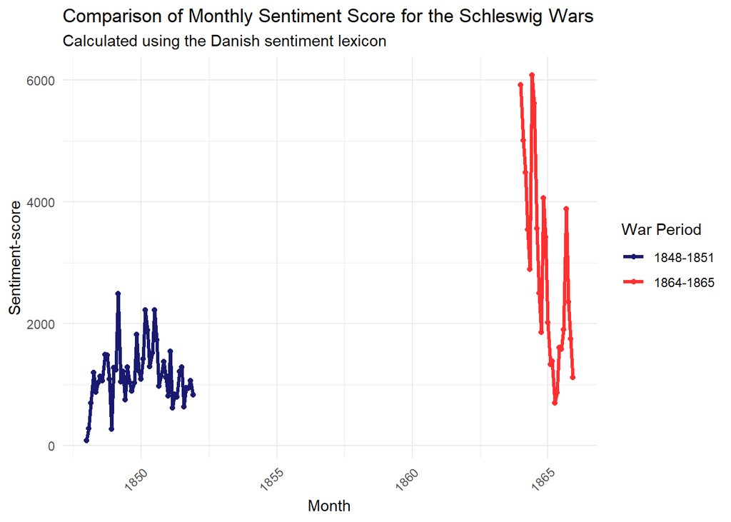

```r
# Visualization of sentiment comparison between the two periods
ggplot(combined_sentiment_scores_danish, aes(x = month, y = sentiment_score, color = war)) +
  geom_line(size = 1.2) +
  geom_point(size = 1.5) +
  labs(
    title = "Comparison of Monthly Sentiment Score for the Schleswig Wars",
    subtitle = "Calculated using the Danish sentiment lexicon",
    x = "Month",
    y = "Sentiment-score",
    color = "War Period"
  ) +
  theme_minimal() +
  scale_color_manual(values = c("1848-1851" = "midnightblue", "1864-1865" = "firebrick1")) +
  theme(axis.text.x = element_text(angle = 45, hjust = 1))
```

# 7. Sentimnet Analysis with AFINN-da

The AFINN-da lexicon is sourced from Github(https://raw.githubusercontent.com/fnielsen/afinn/master/afinn/data/AFINN-da-32.txt).

```r
url <- "https://raw.githubusercontent.com/fnielsen/afinn/master/afinn/data/AFINN-da-32.txt"
afinn_da <- read_delim(url, delim = "\t", col_names = c("word", "score"))
# Match words to sentiment using the AFINN-da dictionary
schleswig_tidy_1848_65_afinn <- schleswig_tidy_1848_65 %>%
  inner_join(afinn_da, by = "word") %>%
  group_by(recordID) %>%
  summarise(sentiment_score = sum(score), .groups = "drop")
```

We compute sentiment over time for all data:

```r
schleswig_tidy_1848_65 <- schleswig_tidy_1848_65 %>%
  mutate(word = str_replace_all(word, "[[:punct:]]", ""))

schleswig_sentiment_monthly <- schleswig_tidy_1848_65 %>%
  mutate(timestamp = ymd_hms(timestamp),
         month = floor_date(timestamp, "month")) %>%
  inner_join(afinn_da, by = "word") %>%
  group_by(month) %>%
  summarise(sentiment_score = sum(score), .groups = "drop")
```

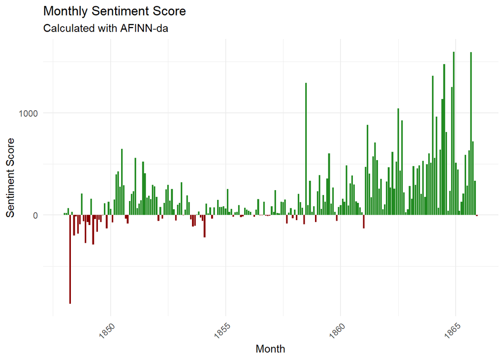

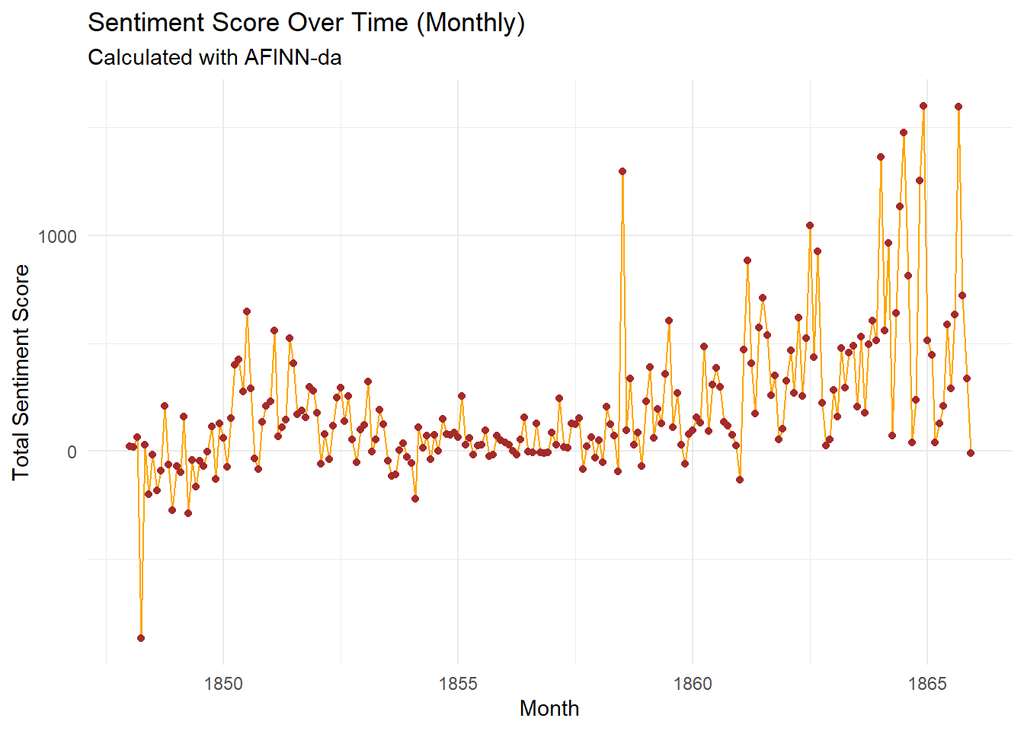

```r
ggplot(schleswig_sentiment_monthly, aes(x = month, y = sentiment_score)) +
  geom_line(color = "orange") +
  geom_point(color = "brown") +
  theme_minimal() +
  labs(
    title = "Sentiment Score Over Time (Monthly)",
    subtitle = "Calculated with AFINN-da",
    x = "Month",
    y = "Total Sentiment Score")
```

# 8. AFINN-da Comparison by War Period

```r
##Define reusable function
prepare_data <- function(df,period) {
  df %>%
    mutate(
      war= period,
      timestamp = ymd_hms(timestamp),
      month =floor_date(timestamp, "month")
    )
}
#Applying the function
schleswig_tidy_1848_51 <- prepare_data(schleswig_tidy_1848_51, "1848-1851")
schleswig_tidy_1864_65 <- prepare_data(schleswig_tidy_1864_65, "1864-1865")


# Combining the two datasets
combined_sentiment_data <- bind_rows(schleswig_tidy_1848_51, schleswig_tidy_1864_65)
```

```r
combined_sentiment_scores <- combined_sentiment_data %>%
  inner_join(afinn_da, by = "word") %>%
  group_by(month, war) %>%
  summarise(sentiment_score = sum(score), .groups = "drop")
```

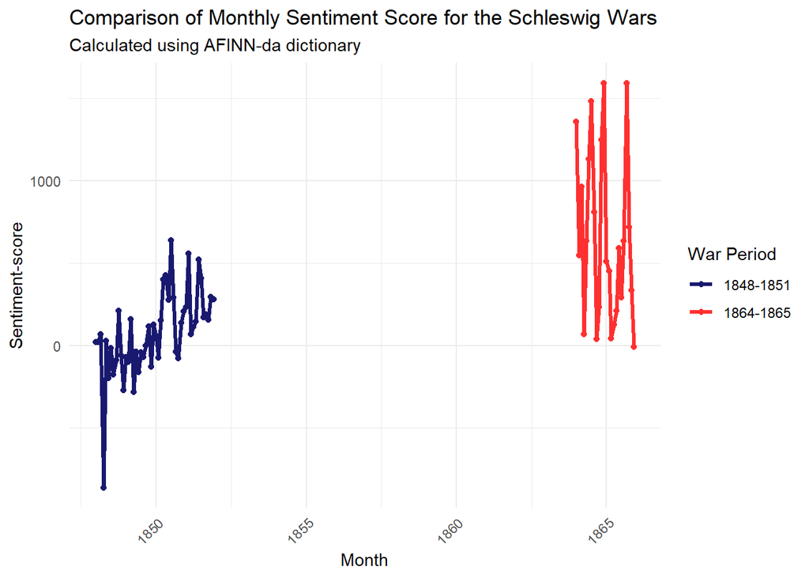

```r
ggplot(combined_sentiment_scores, aes(x = month, y = sentiment_score, color = war)) +
  geom_line(size = 1.2) +
  geom_point(size = 1.5) +
  labs(
    title = "Comparison of Monthly Sentiment Score for the Schleswig Wars",
    subtitle = "Calculated using AFINN-da dictionary",
    x = "Month",
    y = "Sentiment-score",
    color = "War Period"
  ) +
  theme_minimal() +
  scale_color_manual(values = c("1848-1851" = "midnightblue", "1864-1865" = "firebrick1")) +
  theme(axis.text.x = element_text(angle = 45, hjust = 1))
```

# 9. Top words by Period

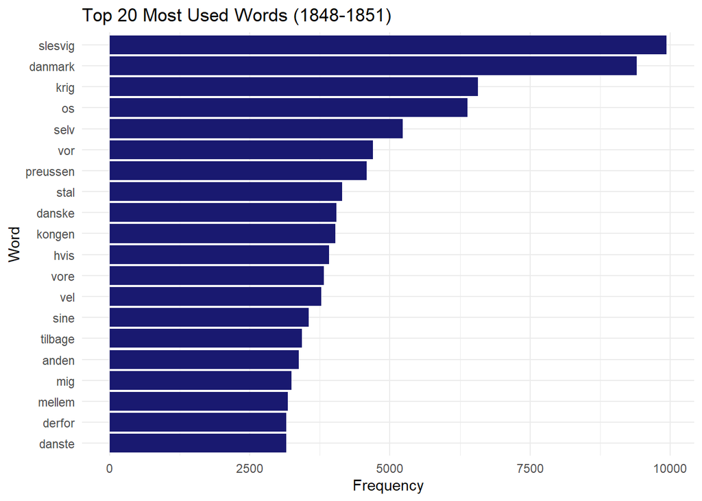

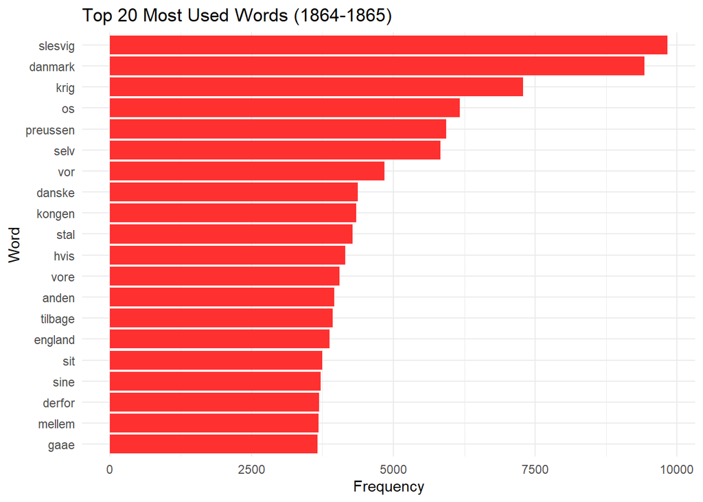

# 10. Reproducibility Notes

- All data was collected from the Danish State Library Labs API.
- Stopwords were obtained from Max Odsbjerg’s Gist.
- The AFINN-da sentiment dictionary is available at this link https://raw.githubusercontent.com/fnielsen/afinn/master/afinn/data/AFINN-da-32.txt”
- Custom Danish lexicon is available here at this link https://github.com/dsldk/danish-sentiment-lexicon/blob/4d50cf4331d50a726599fc93201db77a88d640e3/2_headword_headword_polarity.csv